# Lab6-ANOVA and Variance

Katherine Filpo

2/19/2020

```r
TREE_S15 <- read.csv("~/Documents/BioStats/lab6/Tree_2015 - Sheet1.csv")
#View(TREE_S15)
TREE_F17 <- read.csv("~/Documents/BioStats/lab6/Tree_2017 - Sheet1.csv")
#View(TREE_F17)
library(ggplot2)
```

H<sub>0</sub> My null hypothesis is that there is no differnce between the height of the trees.

H<sub>A</sub> My actual hypothesis is that there is a difference in the height of the trees.

## Bonferroni Correction

Since there are many factors of variation to consider, I would say that my new conclusions are that

corrected P would be 0.05/3 which is 0.01667, as there are tree nteractions happening in this experiment, between A and B, A and C, and B and C.

With this new conclusion, I would say that my conclusion did change, as none of the t values I got would be significant, or at least I would say so without looking more closely at all the p values.

```r
p.adjust(0.02770,n=3,method='bonferroni')
```

```
## [1] 0.0831
```

```r
#
```

## Q2 Analysis of Variance

An anova of the 2015 data and the plot of it.

```r
tree.aov <- aov(TREE_S15$Height ~ TREE_S15$Row)
anova(tree.aov)
```

|  | Df | Sum Sq | Mean Sq | F value | Pr(>F) |
| --- | --- | --- | --- | --- | --- |
| TREE_S15$Row | 2 | 761587.4 | 380793.72 | 4.515606 | 0.02916533 |
| Residuals | 15 | 1264925.7 | 84328.38 | NA | NA |

```r
summary(tree.aov) #does the same thingas anova
```

```
##              Df  Sum Sq Mean Sq F value Pr(>F)
## TREE_S15$Row  2  761587  380794   4.516 0.0292 *
## Residuals    15 1264926   84328
## ---
## Signif. codes:  0 '***' 0.001 '**' 0.01 '*' 0.05 '.' 0.1 ' ' 1
```

```r
print(tree.aov)
```

```
## Call:
##    aov(formula = TREE_S15$Height ~ TREE_S15$Row)
##
## Terms:
##                 TREE_S15$Row Residuals
## Sum of Squares      761587.4 1264925.7
## Deg. of Freedom            2        15
##
## Residual standard error: 290.3935
## Estimated effects may be unbalanced
```

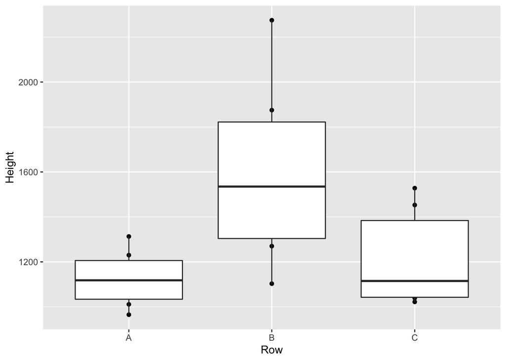

```r
ggplot(TREE_S15, aes(x = Row, y = Height)) +geom_point()+geom_boxplot()
```

## Q3

An anova of the data from 2017 and the plot of it.

```r
tree1.aov <- aov(TREE_F17$Height ~ TREE_F17$Row)
anova(tree1.aov)
```

|  | Df | Sum Sq | Mean Sq | F value | Pr(>F) |
| --- | --- | --- | --- | --- | --- |
| TREE_F17$Row | 2 | 845733.6 | 422866.8 | 1.491164 | 0.2566492 |
| Residuals | 15 | 4253724.5 | 283581.6 | NA | NA |

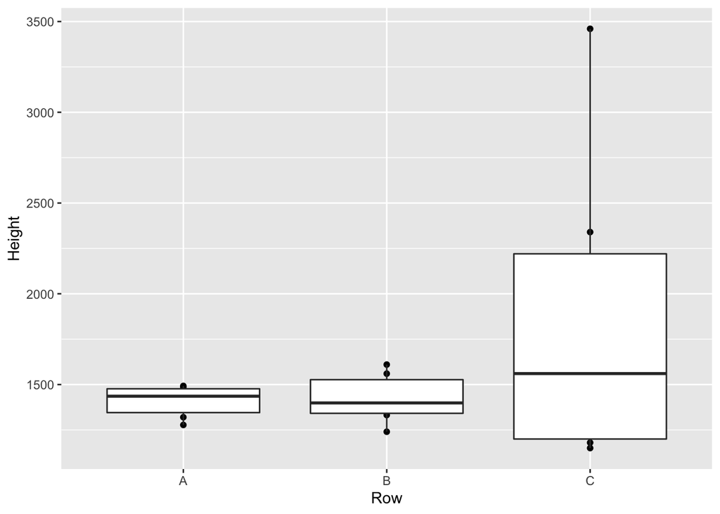

```r
ggplot(TREE_F17, aes(x = Row, y = Height)) +geom_point()+geom_boxplot()
```

also fail to reject H<sub>0</sub> Figure2.There us no ffect of row on tree height(F(2,15) = 1.491; P=257)

## Final TUKEY analysis

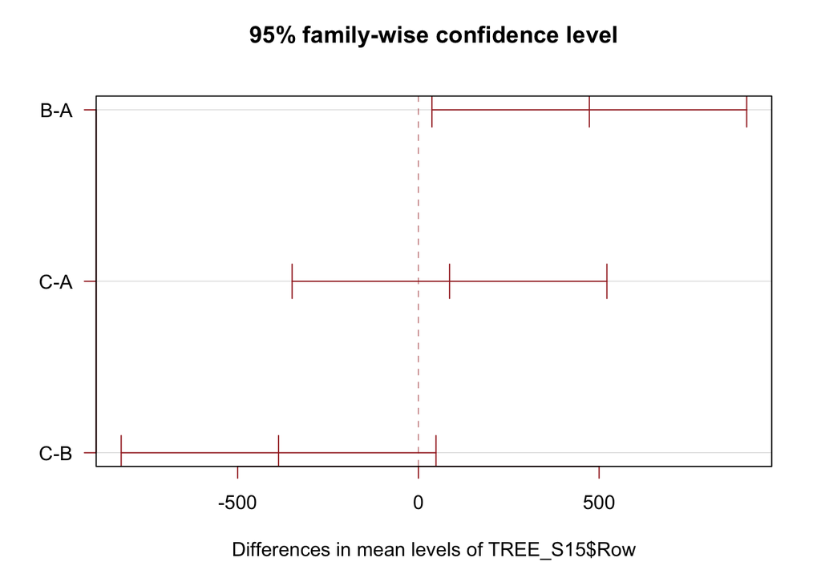

```r
Tukey <- TukeyHSD(x=tree.aov, 'TREE_S15$Row', conf.level = 0.95)
#parenthesis automatically print
plot(Tukey , las=1, col="brown")
```

```r
#this to help test that you are doing the tests
#confidence intervals
```